# Paquete QualityTools

## Diseños factoriales fraccionarios $2^{k-p}$

Para realizar esto se utiliza el método `fracDesign`, vamos a realizar el ejemplo de un diseño $2^{3-1}$, para ello se debe utilizar el argumento `gen='C=AB'`, lo cual quiere decir que el efecto de C es equivalente al de AB:

```r
dfacfrac <- fracDesign(k=3,gen='C=AB',centerCube = 4)
```

Se puede obtener información específica del diseño mediante `summary`:

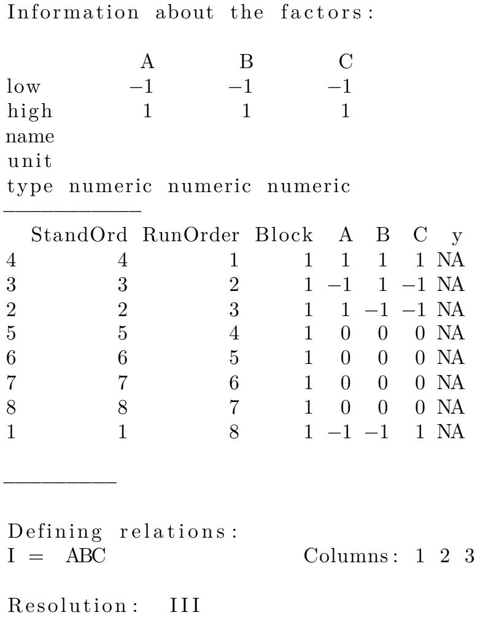

```r
summary(dfacfrac)
```

Vemos que en el modelo se muestra que `I=ABC` y por lo tanto se cumplen las siguientes reglas:

$$\begin{align}
I\times A&=A\\
A\times A&=I\\
A\times B&=B\times A
\end{align}$$

Para encontrar todos los efectos equivalentes se puede usar los comandos:

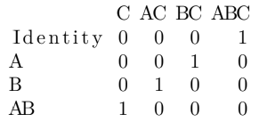

```r
aliasTable(dfacfrac)
```

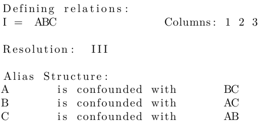

```r
confounds(dfacfrac)
```

Estos diseños se pueden generar asignando los generadores apropiados, el cual se puede elegir entre tabla predefinidas usando el método `fracChoose` y seleccionando el diseño deseado:

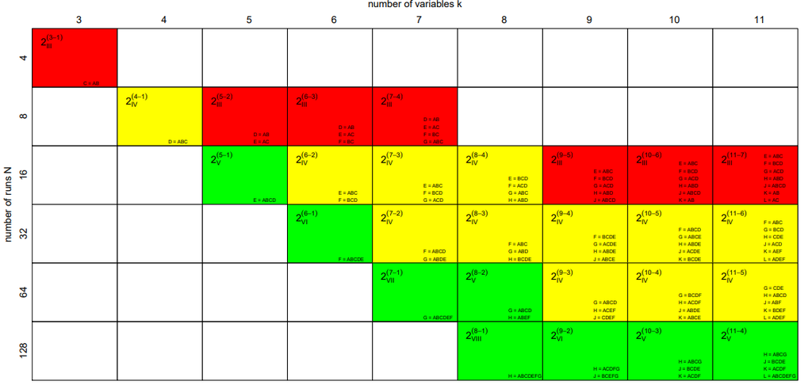

```r
fracChoose()
```

## Diseños replicados y puntos centrales

Se puede crear un diseño replicado con puntos centrales adicionales usando `replicates` y `centerCube`:

```r
dfac1 <- facDesign(k = 3, centerCube = 2, replicates = 2)
```